# STAT 327 Homework 3

We’ll grade your homework by

- opening your “hw3.Rmd” file in RStudio
- clicking “Knit HTML”
- reading the HTML output
- reading your “hw3.Rmd”

You should write R code anywhere you see an empty R code chunk. You should write English text anywhere you see “…”; please surround it with doubled asterisks (`**...**`) so that it will show up as boldface and be easy for us to find.

Include reasonable labels (titles, axis labels, legends, etc.) with each of your graphs.

Name: **Owen Jennings**

Email: **omjennings@wisc.edu**

We’ll use data on housing values in suburbs of Boston. They are in an R package called “MASS.” (An R package is a collection of code, data, and documentation. “MASS” refers to the book “Modern Applied Statistics with S.” R developed from the earlier language, S.) The MASS package comes with the default R installation, so it’s already on your computer. However, it’s not loaded into your R session by default. So we’ll load it via the `require()` command (there’s nothing for you to do here):

```r
require("MASS")
```

Run `?Boston` (outside this R Markdown document) to read the help page for the `Boston` data frame.

Convert the `chas` variable to a factor with labels “off” and “on” (referring to the Charles river).

```r
Boston$chas = factor(Boston$chas, labels=c("off", "on"))
```

How many rows are in the Boston data frame? How many columns?

```r
nrow(Boston)
```

```
## [1] 506
```

```r
ncol(Boston)
```

```
## [1] 14
```

What does a row represent? **A row represents a singular suburb of Boston.**

What does a column represent? **A column represents proportions of different variables between the suburbs of Boston**

Make a density plot (with rug) of tax rates.

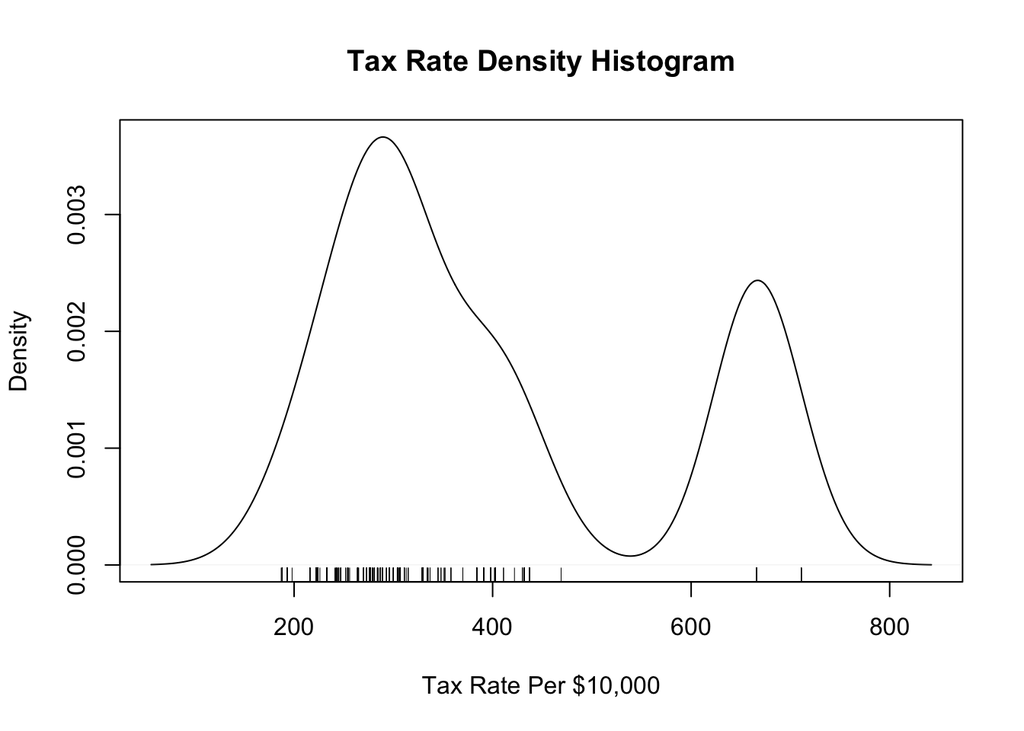

```r
plot(density(Boston$tax), main = "Tax Rate Density Histogram", xlab = "Tax Rate Per $10,000"); rug(Boston$tax)
```

Describe the shape of the distribution of tax rates. **The density plot has a bimodal distribution with much of the data centered around a tax rate of 300 and a smaller peak at approximately 675.**

Note that the distribution shape doesn’t make sense in light of the rug representation of the data. Make a histogram of the tax rates.

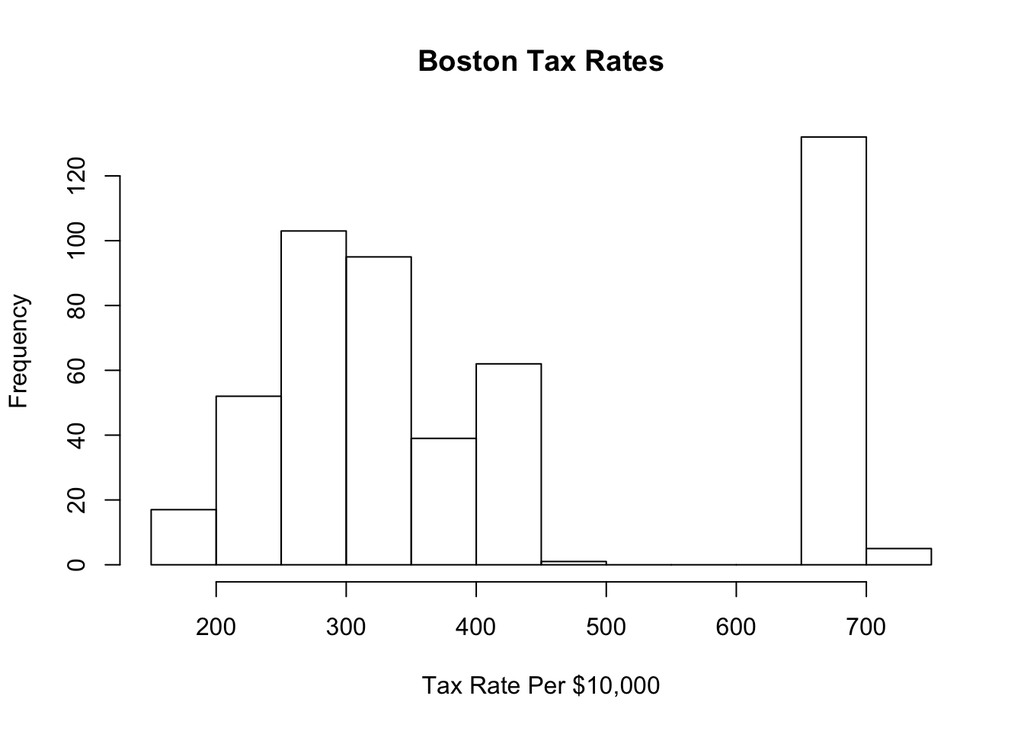

```r
hist(Boston$tax, main = "Boston Tax Rates", xlab = "Tax Rate Per $10,000")
```

Why is the second peak of the density plot so large? In what way is the rug representation of the data inadequate? Write a line or two of code to figure it out, and then explain it.

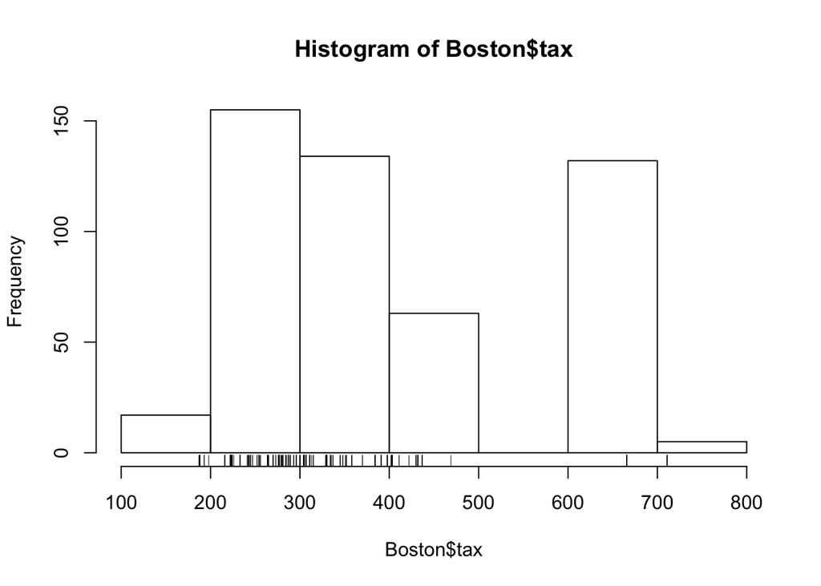

```r
hist(Boston$tax, 5); rug(Boston$tax)
```

Make a barplot of “chas”.

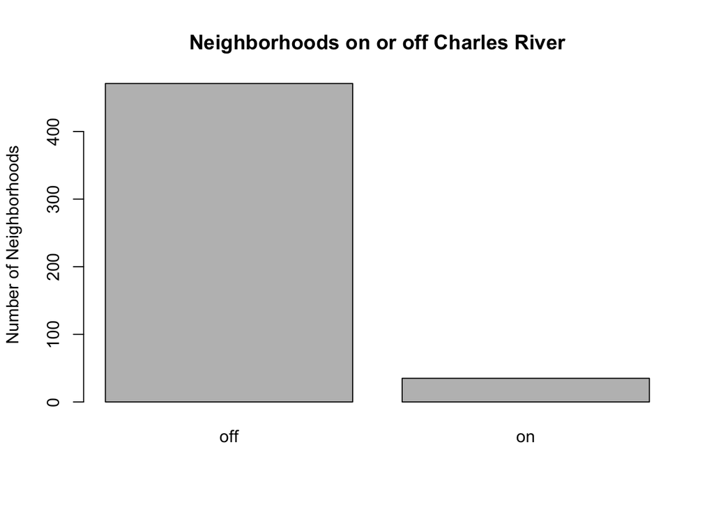

```r
counts = table(Boston$chas); barplot(counts, main = "Neighborhoods on or off Charles River", ylab = "Number of Neighborhoods")
```

How many neighborhoods are on the Charles river?

```r
sum(Boston$chas=="on")
```

```
## [1] 35
```

Make a single graph consisting of three plots:

- a scatterplot of “nox” on the y-axis vs. “dis” on the x-axis
- a (vertical) boxplot of “nox” left of the scatterplot’s y-axis
- a (horizontal) boxplot of “dis” below the scatterplot’s x-axis

Hint: use `layout()` with a 4x4 matrix, using the top-right 3x3 corner for the scatterplot, leaving the bottom-left 1x1 corner blank, and using the other parts for the boxplots.

(An optional challenge, worth 0 extra credit points: remove the axis and plot border from each boxplot.)

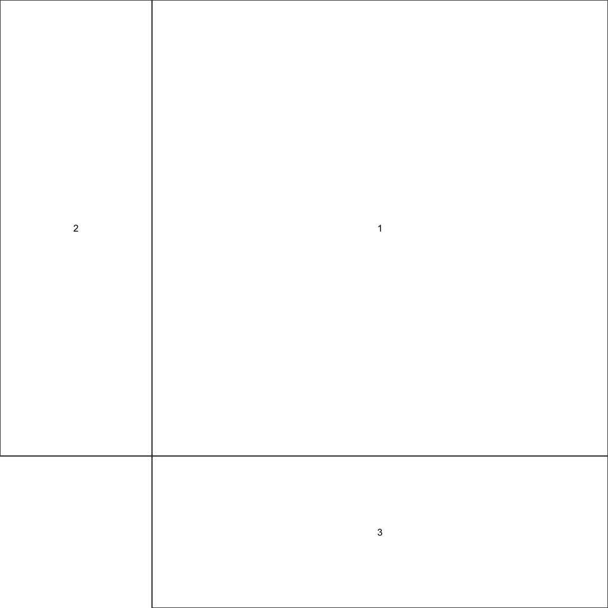

```r
m = matrix(data=c(2,1,1,1,2,1,1,1,2,1,1,1,0,3,3,3), nrow=4, ncol=4, byrow=TRUE)
layout(m)
layout.show(3)
```

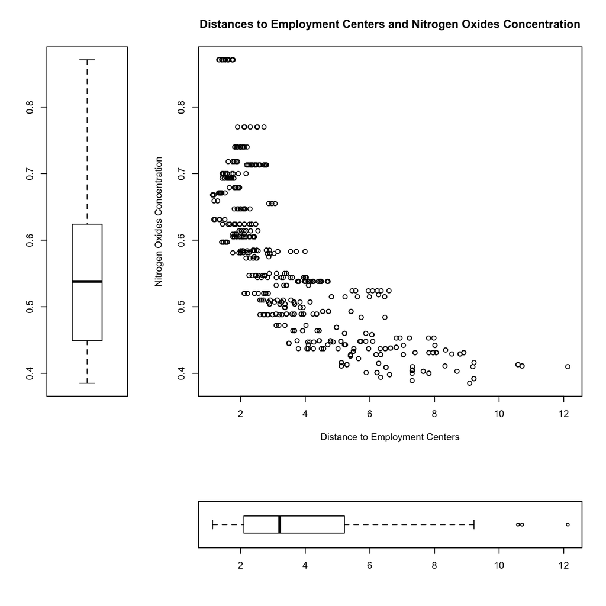

```r
plot(Boston$dis,Boston$nox, main = "Distances to Employment Centers and Nitrogen Oxides Concentration", xlab = "Distance to Employment Centers", ylab = "Nitrogen Oxides Concentration")
boxplot(Boston$nox)
boxplot(Boston$dis, horizontal = TRUE)
```

Look into the highest-crime neighborhood by making a single graph of one column of three rows:

- Find the row number, r, of the neighborhood with the highest “crim”.
- Make a density plot of “crim”. Include a rug to show the data.
- Add a red circle at (x, y) = (max crime rate, 0) to make this maximum crime rate stand out.
- Make a density plot with rug of “medv”, adding a red circle at (x, y) = (medv[r], 0) to see what medv corresponds to the highest crime rate.
- Repeat the last step for “ptratio”.

```r
max(Boston$crim)
```

```
## [1] 88.9762
```

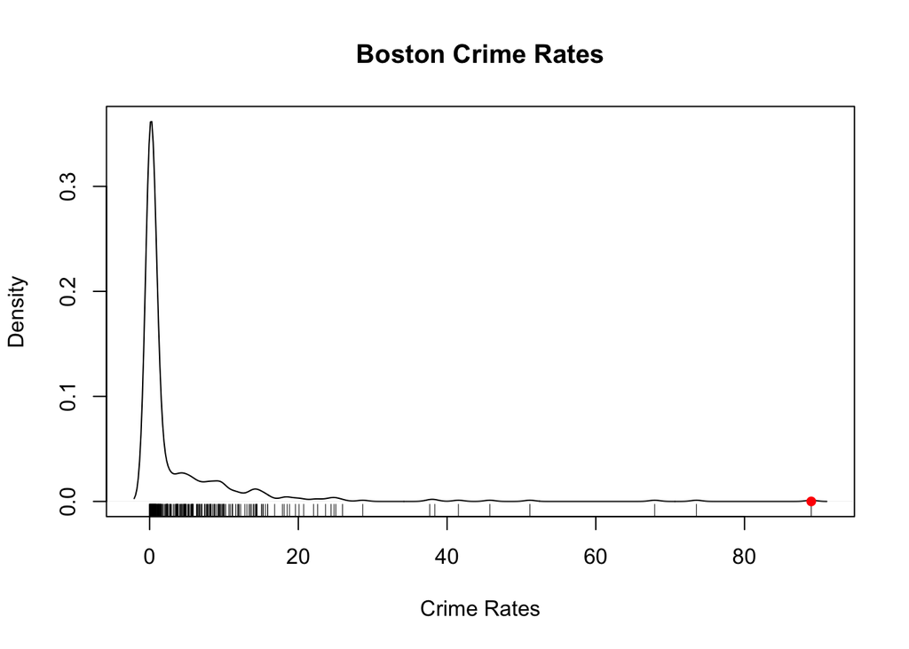

```r
plot(density(Boston$crim), main = "Boston Crime Rates", xlab = "Crime Rates"); rug(Boston$crim); points(88.9762,0,pch = 16, col = "red")
```

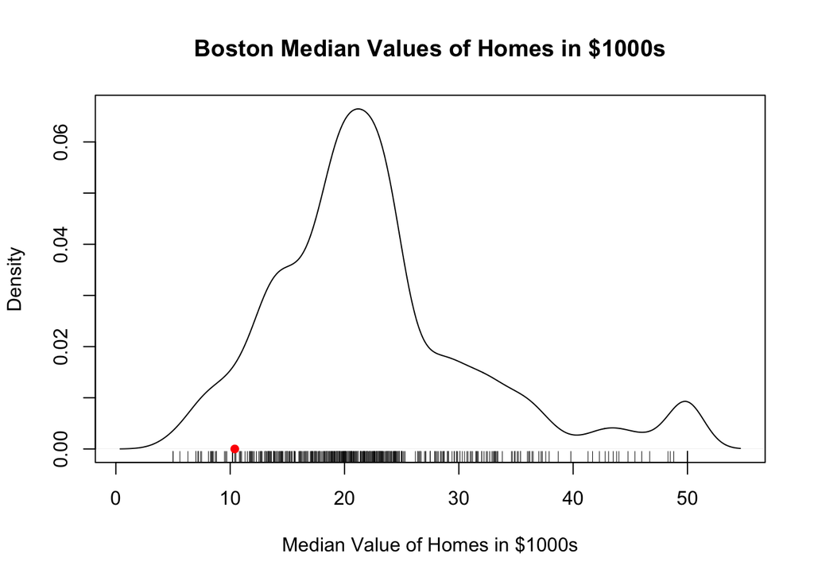

```r
plot(density(Boston$medv), main = "Boston Median Values of Homes in $1000s", xlab = "Median Value of Homes in $1000s"); rug(Boston$medv); points(10.4,0, pch = 16, col = "red")
```

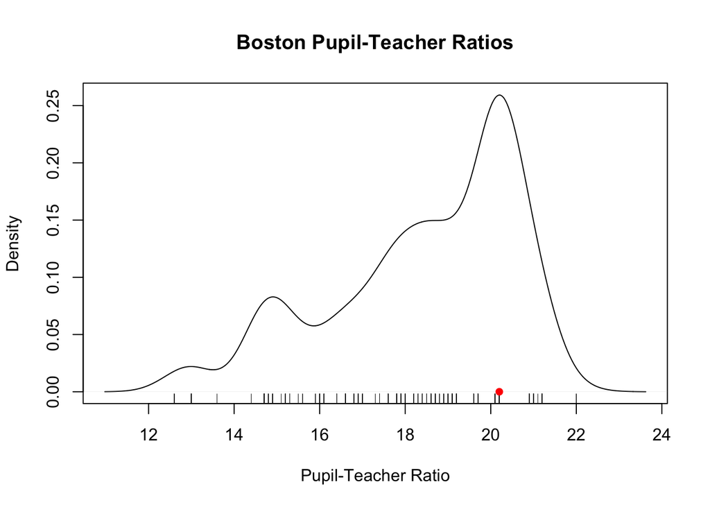

```r
plot(density(Boston$ptratio), main = "Boston Pupil-Teacher Ratios", xlab = "Pupil-Teacher Ratio"); rug(Boston$ptratio); points(20.2,0, pch = 16, col = "red")
```

What do you notice about the ptratio and medv for the highest-crime neighborhood?

**The median value of homes is low and the pupil-teacher ratio is large for the highest crime neighborhood.**